# Basic Raster Analysis with R

## 6 Raster summaries

Now that we know how to import a Raster, subset it, and define its CRS, its a good time to start investigating its values.

The `global()` function can be used to extract values like the average, mean and max cell values. Using the elevation data we have imported, we could work out the highest cell on the map with the following:

```r
max_h <- global(r, "max", na.rm=TRUE)
max_h
```

```
##       max
## test 1736
```

The humble histogram is another useful tool when getting a handle on raster data. Terra allows you to create a frequency distribution histogram with `hist()`:

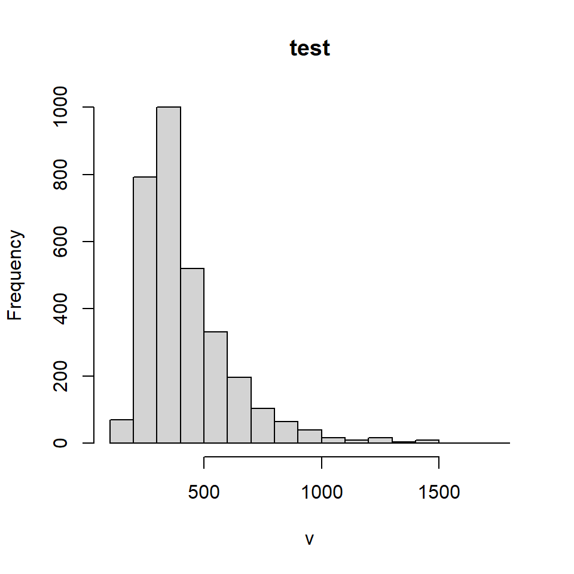

```r
hist(r)
```

Or if a boxplot is more your style, you can use `boxplot()`:

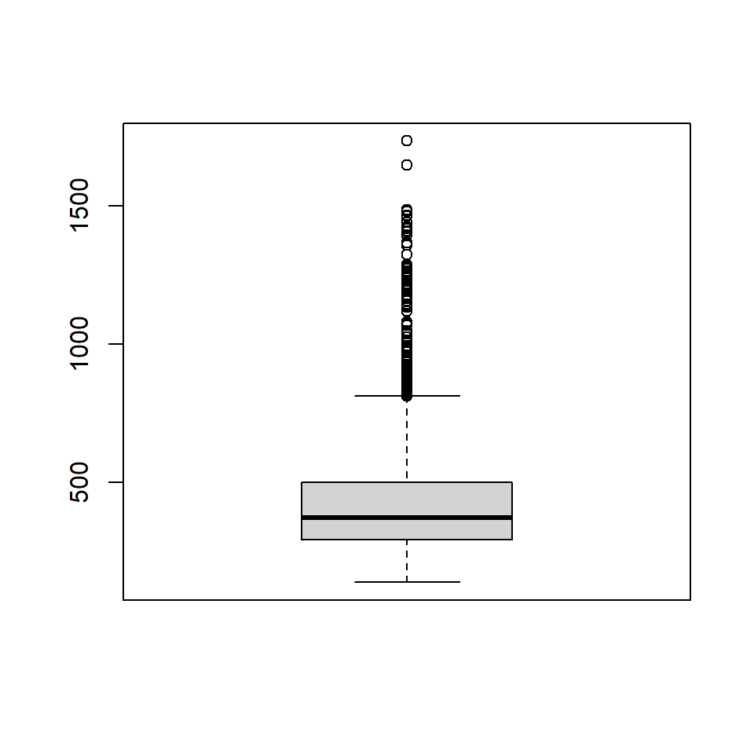

```r
boxplot(r)
```

## 7 Raster data manipulation

There are a huge number of functions within Terra for data manipulation. Here are a few that might be useful.

**aggregate** and **resample** These are used to change the resolution of a SpatRaster.

Aggregate creates a new SpatRaster with with a lower resolution. Users need to provide the factor by which the raster will be reduced.

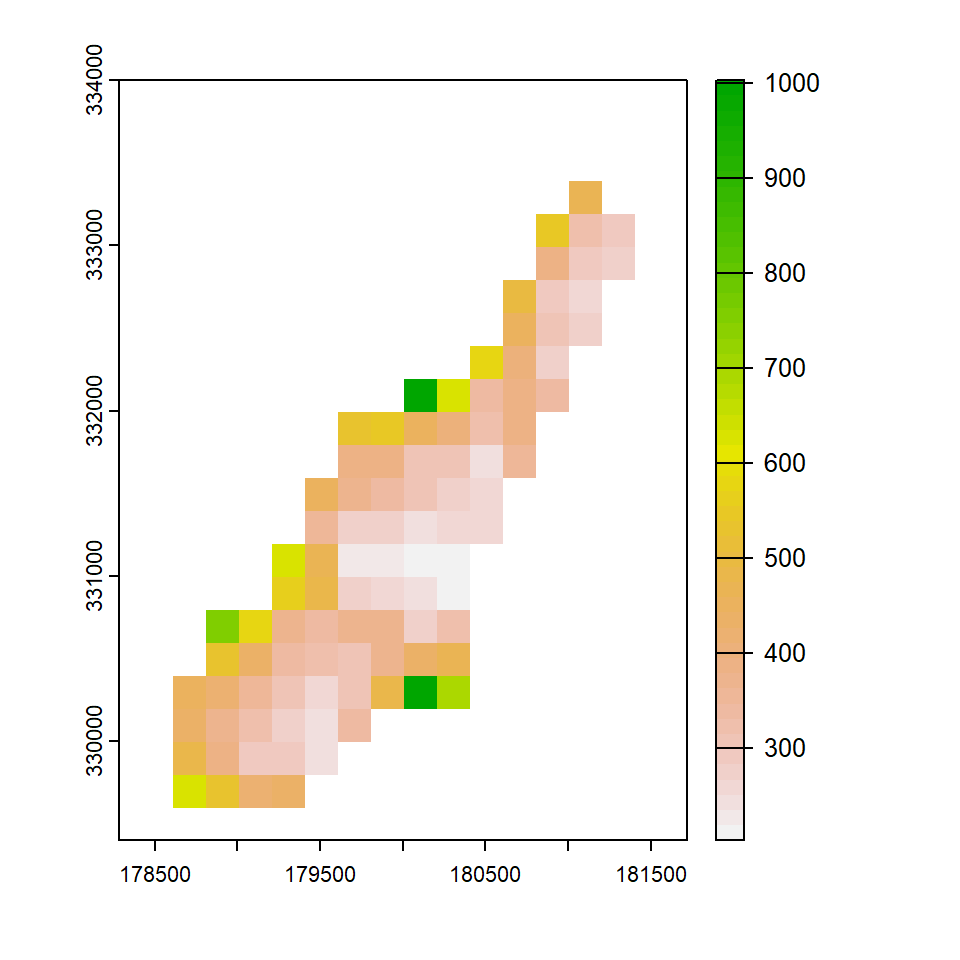

```r
agg <- aggregate(r, fact = 5, fun = 'mean')
plot(agg)
```

You can see that the resolution has been reduced; by a factor of five in this case.

```r
origin(agg) <- c(10.5, 10.5)
```

Then we can resample the original `r` raster to this new agg, with different resolution and a different origin.

```r
rsm <- terra::resample(r, agg, method= 'bilinear')
```

**crop** Cropping is one of the most widely used operations when working with Raster data. To demonstrate a simple crop, we will need to use a SpatVector - the other major data class used by Terra.

On the dataset we have been working on, we will use another function: `spatSample`. Another potentially useful function.

Here, we will randomly generate one point on the elevation raster.

```r
samp <- spatSample(r, 1, as.points=TRUE)
```

Now we can make a buffer centered on this point using the `buffer()` function.

```r
buf <- buffer(samp, 100)
```

Now we can crop the buffered area.

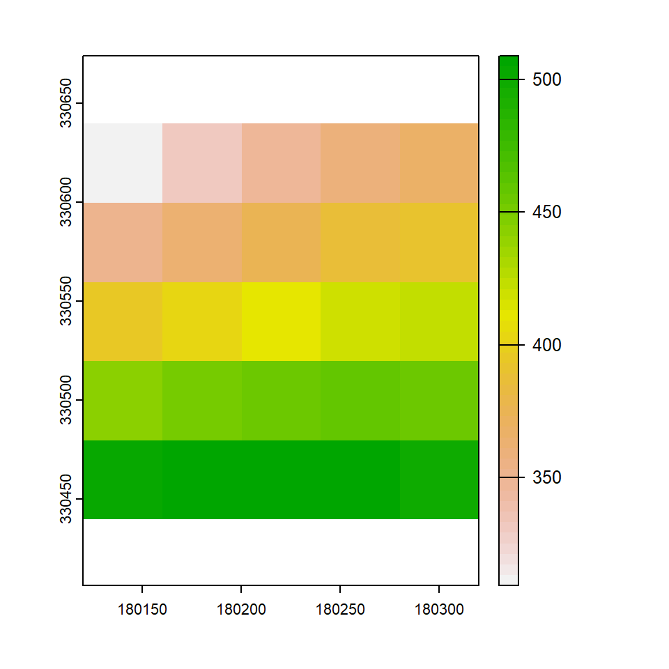

```r
cropped <- crop(r, buf)
plot(cropped)
```

**stretch**

Another function that can be required is to stretch the values to a given range. For example, classification can require data that is normalised to 8bit: 0-255. This can be handy if you want to normalise rasters on different scales, such as elevation and reflectance.

```r
str <- stretch(r) #defaults to 0-255
```

**focal** Another potentially useful tool is `focal()`, which can be used to clean data. Focal uses a moving window with size `w` and a function to average neighboring cells. Lets do that with the elevation dataset.

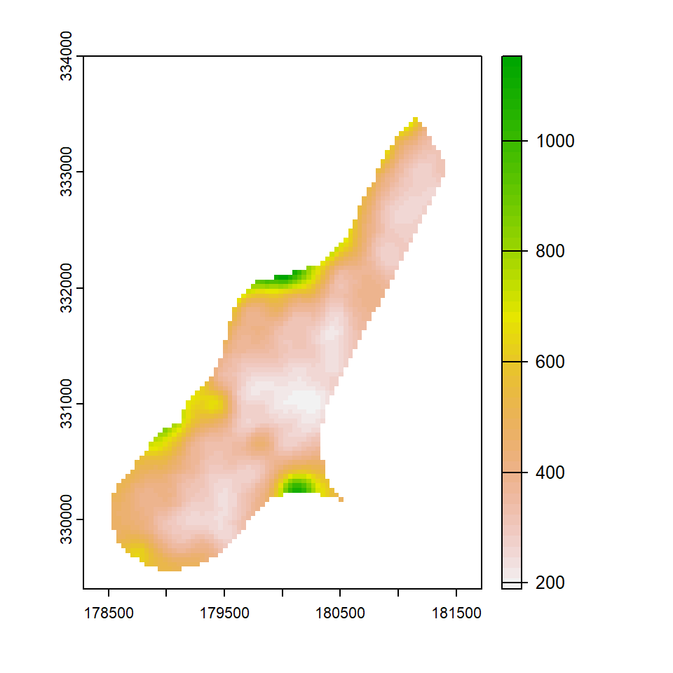

```r
f <- focal(r, w=5, fun="mean")
plot(f)
```

## 8 Compatibility between Raster and Terra

If you are used to using `Raster`, it is not too difficult switch between Raster classes (RasterLayer, RasterStack etc) and SpatRaster using `rast()` function.

Here is an example.

First install the Raster packages, which is available on CRAN.

```r
install.packages("raster")
library(raster)
```

Now, using the sample data loaded into Raster, we can create a Raster stack of the r logo.

```r
stac <- stack(system.file("ex/logo.tif", package="terra")) #This is a raster stack
rst <- rast(stac) #now this is a SpatRaster
```

## 9 A real world example with drone data

In this example, we will use some of my drone data collected from savanna woodlands in north Australia.This is a typical example where we have an orthomosaic, which was derived from a camera (RGB), and a canopy height model, which was derived from LiDAR point cloud.

First, for the sake of this example, we need to reduce the size of the orthomosaic (1.3+GB is too big). But in reality, we might want that much resolution, depending on what we are trying to do.

```r
orthopath <- ".../hacky_sac/2022-02-23 Basic raster analysis with R/plot1_ortho.tif"
ortho_reduced_path <- "...2022-02-23 Basic raster analysis with R/plot1_ortho_reduced.tif"
ortho <- rast(orthopath)
res(ortho) #check the resolution

#now lets reduce it down with aggregate

#note the filename variable lets us write directly to file
terra::aggregate(ortho, fact = 10, fun = 'mean', filename = ortho_reduced_path)
ortho_reduced <- rast(ortho_reduced_path)
res(ortho_reduced)
```

We can download the reduced orthomosaic [here](https://cloudstor.aarnet.edu.au/plus/s/wCiK6OgptZMoJku)

And the chm [here](https://cloudstor.aarnet.edu.au/plus/s/U5MUyCHYxvWxL6g)

The first thing to do is load the rasters as SpatRasters in R.

```r
homefolder <- "C:/Users/uqmrudg1/Downloads" #where did you download the files to?
chm_path <- paste0(homefolder, "/", "plot1_chm.tif")
ortho_path <- paste0(homefolder, "/", "plot1_ortho_reduced.tif")

#now read in the files using terra
chm <- rast(chm_path)
ortho <- rast(ortho_path)
```

We will often want to merge different layers into a single raster. Before we can do this, we need to make sure the crs, resolution, origin and extent match.

```r
#do the crs match?
crs(chm) == crs(ortho)
#do the origins match?
origin(chm) == origin(ortho)
#do the resolutions match?
res(chm) == res(ortho)
#do the extents match?
ext(chm) == ext(ortho)
```

We should see that the CRS matches, but nothing else.

We can use the `resample()` function can help to match the geometries. If we want to keep the higher resolution of the orthomosaic, we can run:

```r
chm_resampled <- resample(chm, ortho, method = "bilinear")
#now, geometry should match
res(chm_resampled) == res(ortho)
origin(chm_resampled) == origin(ortho)
ext(chm_resampled) == ext(ortho)
```

On the right track. lets plot them to have a look.

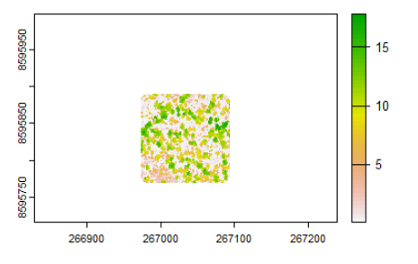

```r
plot(chm_resampled)
```

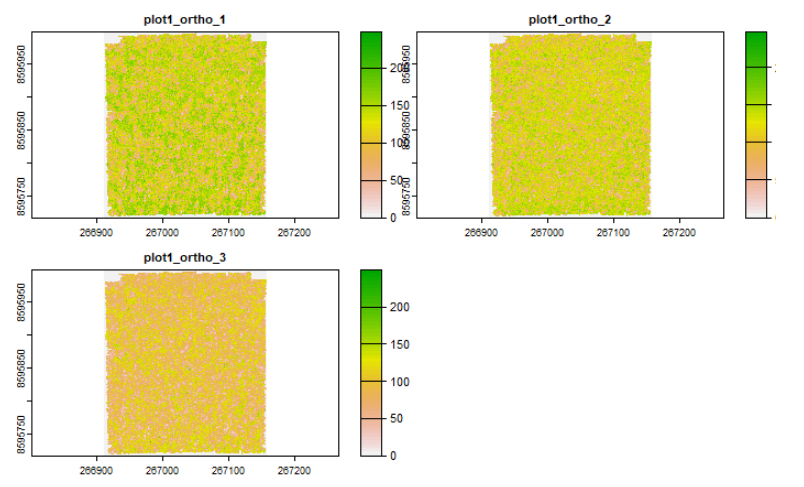

```r
plot(ortho)
```

We can see that even though they have the same extent - as enforced by the `resample()`, there are a lot of blank cells around the CHM.

Lets get rid of those blank (NA) cells using the `trim()` function.

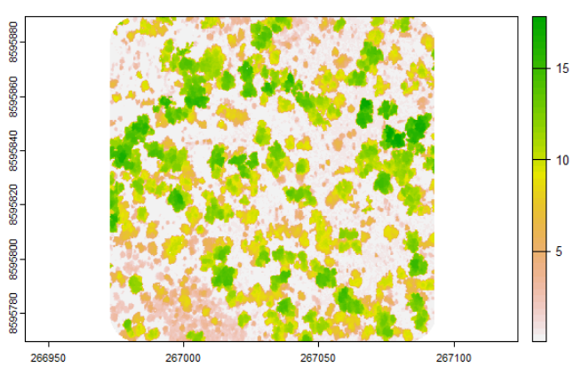

```r
chm_resampled <- trim(chm_resampled)
plot(chm_resampled)
```

That’s better, now lets crop the orthomosaic using the extent of the CHM.

```r
ortho_cropped <- crop(ortho, chm_resampled)
```

Now the everything should match, and we can finally combine these layers into a single `SpatRaster` object. For this, you can just concatenate the layers: c(layer1, layer2, layer3).

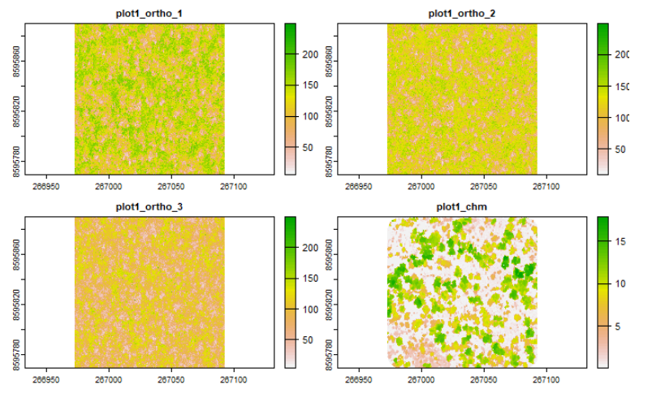

```r
combined <- c(ortho_cropped, chm_resampled)
plot(combined)
```

The band names don’t make a lot of sense at this point, so we can rename them using the `names()` function.

```r
names(combined) <- c('red', 'green', 'blue', 'chm')
```

Finally, prior to doing some analysis, we might want to stretch the chm to 8bit - so its not under-weighted compared to the RGB data. This calls for the `stretch()` function.

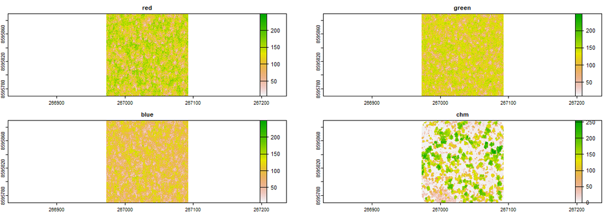

```r
combined$chm <- stretch(combined$chm)
plot(combined)
```

Now we have a raster stack we can work with!

## 10 A cool new package called Layer

One fun little package I stumbled on recently is called `layer`. It doesn’t really serve a purpose in terms of analysis, but will be good for making figures that demonstrate the datasets used.

[figure not shown]

Unfortunately, `Layer` calls for `Raster` data, but as we already know, it’s easy to convert `Raster` to `SpatRaster` objects.

But before we get into that, lets further reduce the resolution of the `combined` `SpatRaster`, as there is a lot going on in the background of `Layer` and its pretty slow.

```r
combined_lowres <- terra::aggregate(combined, fact = 10) #10x less rows and columns
```

```r
install.packages("layer")
install.packages("raster")
library(layer)
library(raster)
```

Now we can provide the layers to `tilt_map`, then `plot_tilted_map`, to create a nice looking tilted stack demonstrating our data set. Note within the tile_map function, we convert the SpatRaster to Raster with the `raster()` function.

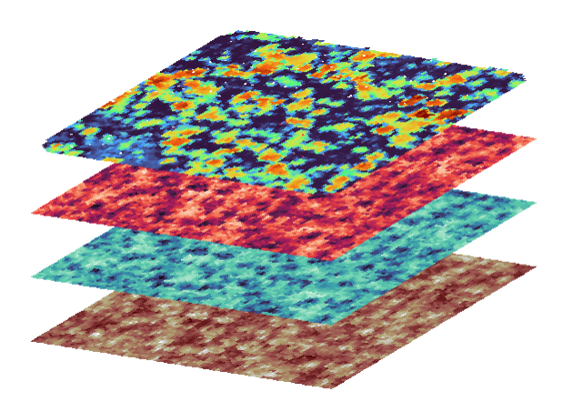

```r
tilt_map_1 <- tilt_map(raster(combined_lowres$red))
tilt_map_2 <- tilt_map(raster(combined_lowres$green), x_shift = 0, y_shift = 50)
tilt_map_3 <- tilt_map(raster(combined_lowres$blue), x_shift = 0, y_shift = 100)
tilt_map_4 <- tilt_map(raster(combined_lowres$chm), x_shift = 0, y_shift = 150)

map_list <- list(tilt_map_1, tilt_map_2, tilt_map_3, tilt_map_4)

plot_tiltedmaps(map_list,
                layer = c("value", "value", "value", "value"),
                palette = c("bilbao", "mako", "rocket", "turbo"),
                color = "grey40")
```